# Network Monitoring

using an Infrastructure as Code approach

ESNOG GORE19, April 7th, 2017

## Agenda

- Some Context
- Requirements
- Proposed Solution
- Dynamic Infrastructure
- Lessons Learned
- Next Steps

## Some Context

## About Me

- **DevOps Network Engineer** at *Schibsted Media Group*
- Former **Network Engineer** at *CCMA / TV3*

  ```python
  def how_to_get_in_contact(channel):
  username = 'chadell'
  if channel in ['linkedin', 'github']:
      return username
  elif channel == 'twitter':
      return "{}0".format(username)
  elif channel == 'email':
      return "{}@gmail.com".format(username)
  else:
      return "You will find me running in some mountain"
  ```

## Schibsted Media Group

[figure not shown]

## Platform Edge Network Services

- Edge Networking
- DDoS Mitigation
- DNS

## Requirements

## Use-case

- Provide **<1.2ms** network latency to a specific Provider
- Peering in Amsterdam and Frankfurt area
- Use a IaaS provider who provide virtual routers
- Future new PoPs over other IaaS providers or On-premises

## What is expected from us?

- Router Configuration
  - High-availability, critical business operation
  - No network engineers to operate it
  - DevOps teams, building and running it, easy to adapt
- Network Monitoring
  - Integrate with current SaaS monitoring solutions

## Proposed Solution

## Automate configuration provisioning

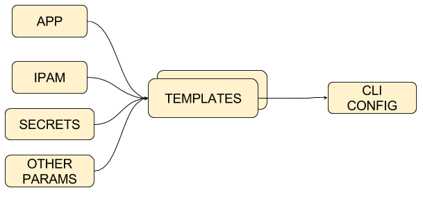

## APP.yaml

```yaml
groups:
  - address-group:
    name: 'STAFF-ACCESS'
    addresses:
      - '5.148.132.151'
firewall:
  - rule:
    source: 'STAFF-ACCESS'
    destination: 'EXPOSED-SERVERS'
    protocol: 'tcp'
    destination_port: '22'
    action: 'accept'
nat:
  - rule:
    internal_ip: '159.122.8.231'
    external_ip: '79.171.28.1'
```

## IPAM.yaml

```yaml
# Interfces configuration
interfaces:
  - name: 'bond1.1963'
    parent: 'bond1'
    vlan: '1963'
    ip_address: '172.16.0.18/29'
    priority: '200'
    ip_vrrp:
      - ip: '159.122.8.225/28'
# BGP Configuration
asn: 44588
networks:
  - '79.171.28.0/24'
router_id: '10.104.135.88'
peers:
  - ip: '81.95.156.233'
    asn: 36351
    med: False
    localpref: False
  - ip: '10.104.135.70'
    asn: 44588
    multi_hop: 0
```

## Secrets and other params

```json
{"fqdn": "router5",
 "public_ip": "11.1.1.1",
 "mgmt_ip": "10.1.1.5",
 "model": "cisco",
 "location": "Amsterdam",
 "user": "whatever",
 "auth_key": "whatever",
 "priv_key": "whatever",
 "auth_protocol": "usmHMACMD5AuthProtocol",
 "priv_protocol": "usmDESPrivProtocol",
 "oids": {
    "1.3.6.1.2.1.1.7": "sysServices",
    "1.3.6.1.2.1.2.2.1": "ifOutUcastPkts"
    },
 "mibs": {
    "IF-MIB": {
        "table": "ifTable",
        "symbols": ["ifInOctets", "ifOutOctets"],
        "metric_tags": {
            "tag": "interface",
             "column": "ifDescr"
            }
        }
    }
}
```

## Templates

```
    # BGP peerings
{% for peer in config['peers'] %}
    {% if peer.multi_hop != 0 %}
    set protocols bgp {{ config['asn'] }} neighbor {{ peer.ip }} ebgp-multihop {{ peer.multi_hop }}
    {% endif %}
    {% if peer.med %}
    set protocols bgp {{ config['asn'] }} neighbor {{ peer.ip }} route-map export 'MED100'
    {% endif %}
    {% if peer.localpref %}
    set protocols bgp {{ config['asn'] }} neighbor {{ peer.ip }} route-map import 'SETLOCALPREF'
    {% endif %}
    set protocols bgp {{ config['asn'] }} neighbor {{ peer.ip }} prefix-list export 'EXPORT-IP-RANGES'
    set protocols bgp {{ config['asn'] }} neighbor {{ peer.ip }} remote-as {{ peer.asn }}
    set protocols bgp {{ config['asn'] }} neighbor {{ peer.ip }} soft-reconfiguration 'inbound'
{% endfor %}
```

## Integrate monitoring

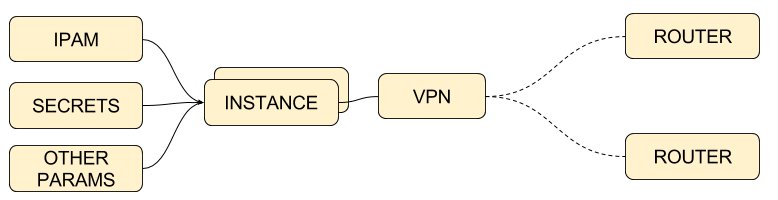

## Dynamic Infrastructure

## VCS

> Every line of code should be controlled
- Define Instance Template
- Create Dynamic Infrastructure
  - Monitoring Instance
  - Testing Routers
- Provision new Routers in the DataBase
- SNMP template generator

## CI

1. Install
2. Test
   - Unit testing
   - Functional testing
3. Deploy
   - Python Pypi
   - RPM package

## CD

0. From a source code in a VCS
1. Configuration
   - trigger
2. Bake
   - Provider
   - Base OS
3. Deploy
   - Account / Environment
   - Network
   - Capacity
   - Secrets and permissions

## DEV / PRE / PRO

## DATABASE / KMS

## Testing

## IPAM

## Appliction Driven

## Lessons learned

- Don't have fear, there are friends willing to help!
- Learn failure after failure
- Start small, solve concrete issues
- When everything is running, destroy it and recreate from scratch

## Next Steps

- Automatic deployment